# Wyniki

Martyna Czajkowska, Jan Cichowlas

# Opis projektu

Poniższa praca ma na celu odpowiedź na trzy postawione przez nas pytania badawcze. Dane, które wybraliśmy, aby na nie odpowiedzieć, pochodzą z portali: Fitness, Gaming, Languagelearning oraz Matrialarts. Wszystkie z nich udostępniane są przez sieć Stack Exchange.

# Problem 1

### Opis

Pierwsze z pytań brzmi: Co wpływa na sukces użytkownika na forum? Odpowiedzi szukaliśmy na przykładzie forum Gaming. Przez “sukces” rozumiemy zarówno wysoką ocenę jego postów, jak i ich popularność.

### Definicja “sukcesu”

Zauważmy, że dla każdego posta wyznaczyć można parametr będący iloczynem jego oceny (Score) i liczby wyświetleń (ViewCount). Taki parametr nazywamy “sukcesem”. Jeden użytkownik może jednak być autorem wielu postów. Wprowadzamy więc dwa dodatkowe parametry. Pierwszy z nich to “sukces absolutny” będący sumą “sukcesu” wszystkich postów danego użytkownika, drugi zaś to “sukces średni” będący średnią arytmetyczną “sukcesu” wszystkich postów. Dodatkowo, ze względu na swój absolutny i średni sukces, użytkownicy zostali podzieleni na pięć grup, od najgorszej do najlepszej: “Unsuccessful”, “Normal”, “Successful”, “Brilliant” i “Elite”. Chcąc dowiedzieć się, co wpływa na sukces użytkowników, badamy więc cechy wspólne, którymi charakteryzują się osoby zaklasyfikowane do danej grupy.

### Model 1

Czynnikiem, który może pozytywnie wpływać na sukces użytkowników, jest czas użytkowania konta. Im dłużej ktoś korzysta z forum, tym więcej ma doświadczenia i tym lepsze powinny być jego posty. Czy tak rzeczywiście jest? Co wykazała analiza?

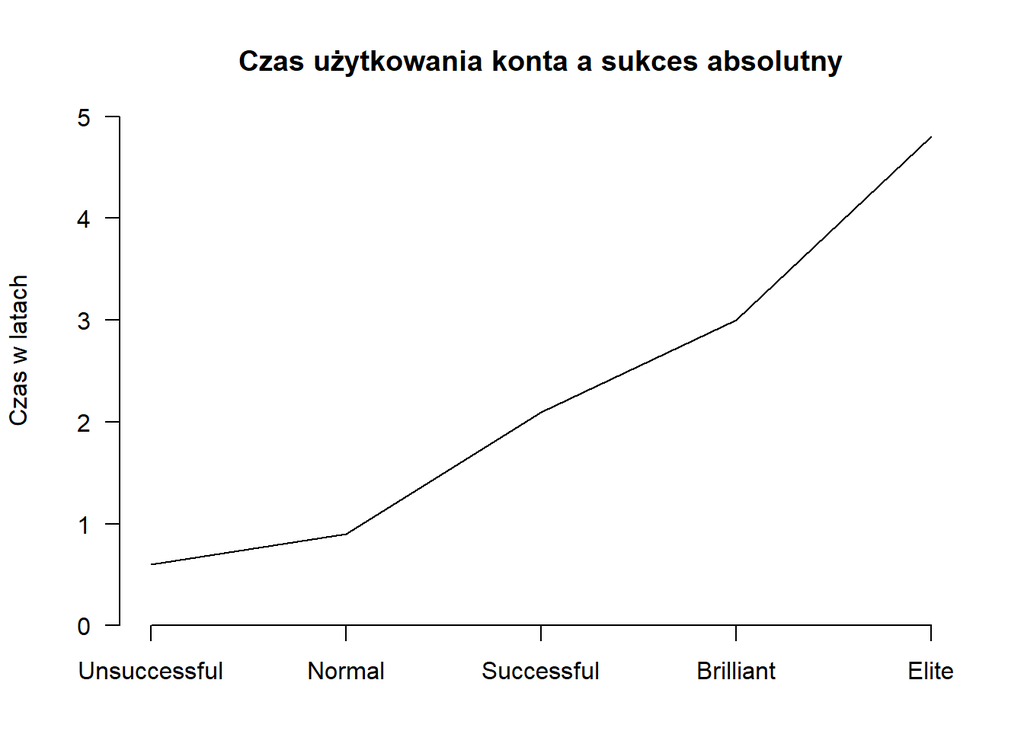

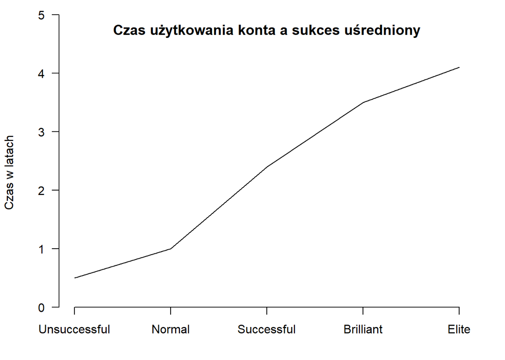

Powyższe wykresy potwierdzają nasze początkowe przypuszczenia. Doświadczenie rzeczywiście wpływa pozytywnie na sukces postów danego użytkownika.

### Model 2

Innym czynnikiem, który może pozytywnie wpływać na popularność postów, jest ich kontrowersyjność. Przez “kontrowersyjność” rozumiemy średni stosunek głosów negatywnych do wszystkich głosów oddanych na posty danego użytkownika. Czy budzenie w innych negatywnych emocji wpływa na sukces?

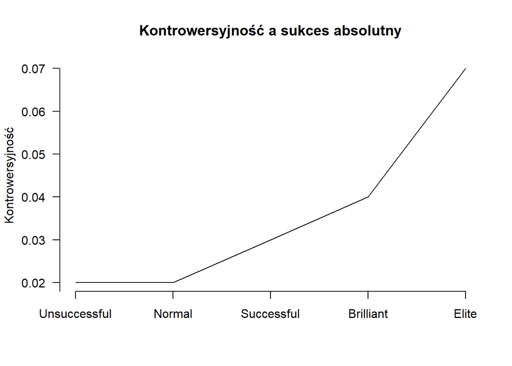

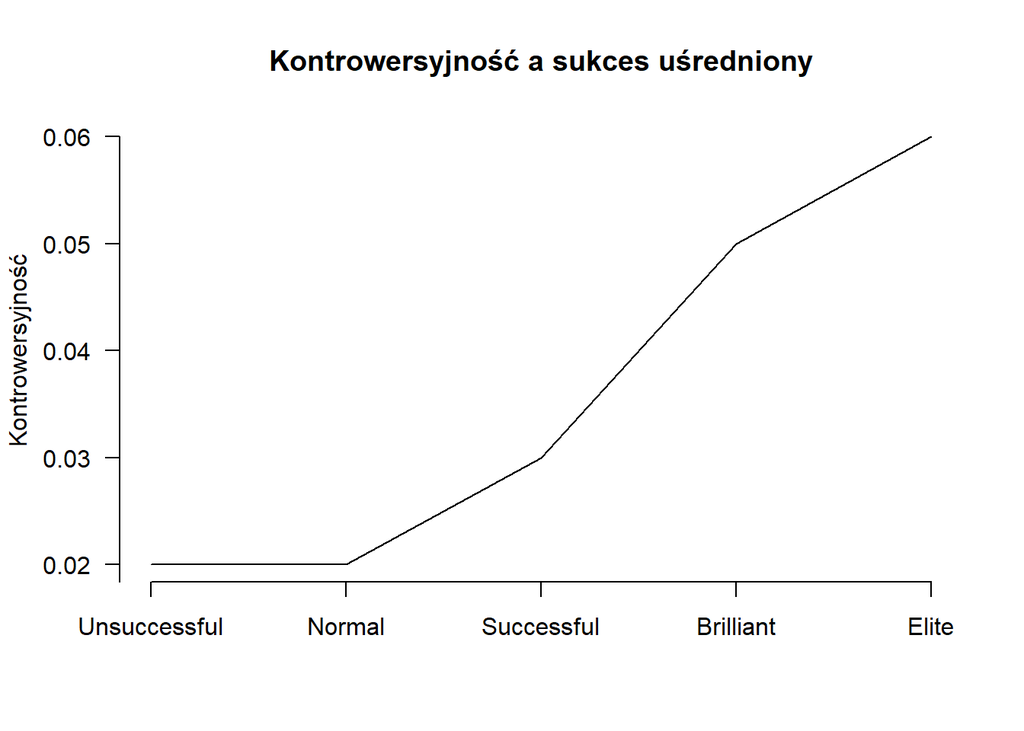

Powyższe wykresy pokazują, że kontrowersyjność również wpływa na sukces użytkowników. Jej efekty jednak widoczne są dopiero w bardziej zaawansowanych grupach.

# Problem 2

## Opis

Jakie zainteresowania mają użytkownicy forum Gaming? Sprawdziliśmy to na przykładzie forów Fitness, Languagelearning oraz Martialarts. Poniższy wykres przedstawia rozkład tych zainteresowań.

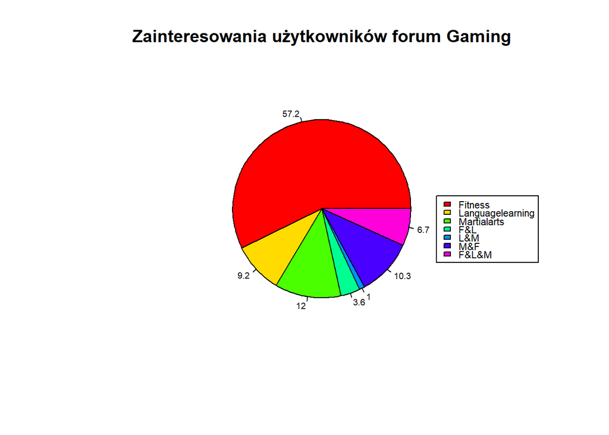

Widzimy więc, że znaczna większość użytkowników forum Gaming udziela się również na forum Fitness.

# Problem 3

## Opis

Jak dużo postów pisanych było na forach w ostatnich latach? Sprawdziliśmy to na przykładzie forów Fitness, Languagelearning oraz Martialarts.

Poniżej znajduje się animowany wykres przedstawiający zależność liczby postów pisanych na każdym forum od roku (wartość 0 oznacza, że forum nie było dostępne w danym roku).

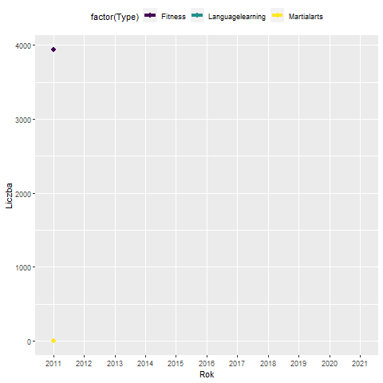